# Explanatory data analysis

Jong-June Jeon

May, 2018

## Frequency of univariate varable

## package

- `plotrix`
- `vioplot`
- `vcd`

## introduction

```
* 범주형 변수의 예: 성별, 지지후보, 혈액형 등
* 범주형 변수의 요약치: 빈도, 상대빈도
* 범주형 변수의 요약치에 대한 시각화

    + 막대그래프
    + 파이차트
    + 기타 유용한 도구
```

## barplot

- 미국 지역별로 몇 개의 주가 있을까?
  - `state.region`을 출력해보자.

```r
counts = table(state.region)
counts
barplot(counts, main = "simple bar chart",
xlab = "region", ylab = "freq")
```

- `table` 함수의 사용: `state.region` 변수의 빈도를 계산한다.
- `barplot`함수는 `counts`변수의 값을 이용하여 막대그래프를 그린다.
- `xlab, ylab`은 축 이름을 붙인다.

## barplot

```
## state.region
##     Northeast         South North Central          West
##             9            16            12            13
```

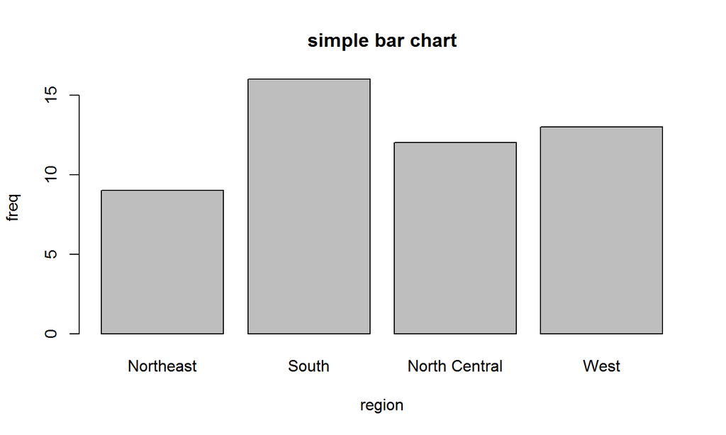

## barplot

- `mtcar`데이터는 자동차의 성능 정보에 관한 데이터다.
  - 어떤 종류의 차가 있나?
  - mtcars 데이터의 cyl 변수의 빈도를 barplot으로 그려보자

## barplot

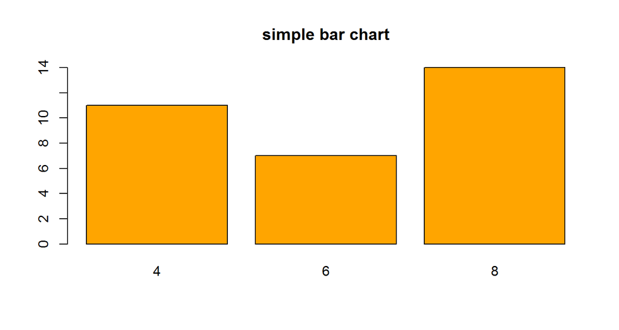

```r
freq.cyl =table(mtcars$cyl)
barplot(freq.cyl, main = "simple bar chart", col ="orange")
```

## barplot

- 변수에 이름을 붙여주기 위해서 `'barplot` 함수 내에서 `names.arg`옵션에 문자열을 아래와 같이 지정한다.

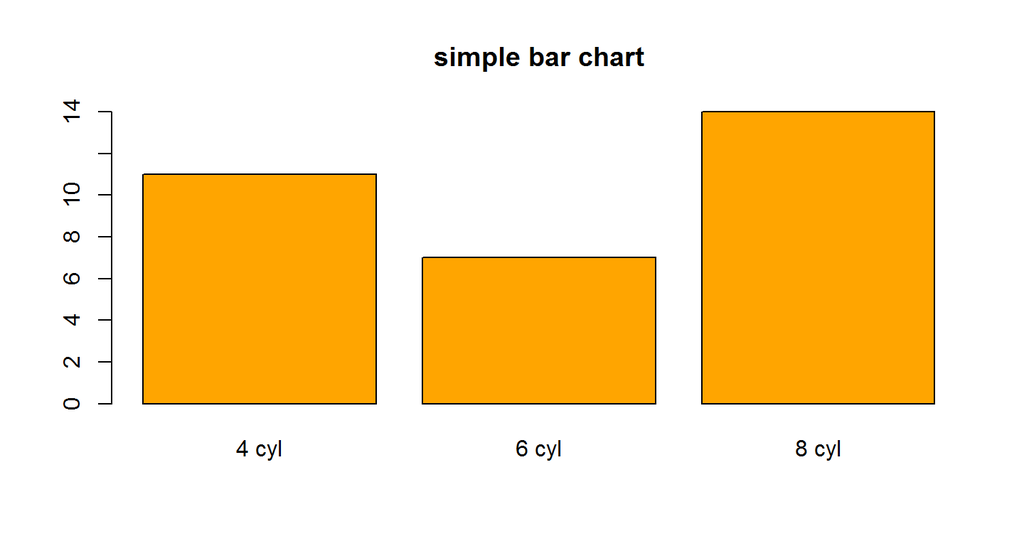

```r
cyl.name =  c("4 cyl", "6 cyl", "8 cyl")
barplot(freq.cyl, main = "simple bar chart", col ="orange",
names.arg = cyl.name)
```

## pie chart

```r
cyl.name2 = paste0( cyl.name, "(", freq.cyl, "%)")
pie(freq.cyl, labels = cyl.name2,
    col = rainbow(length(freq.cyl)), main = "pie chart")
```

## pie chart

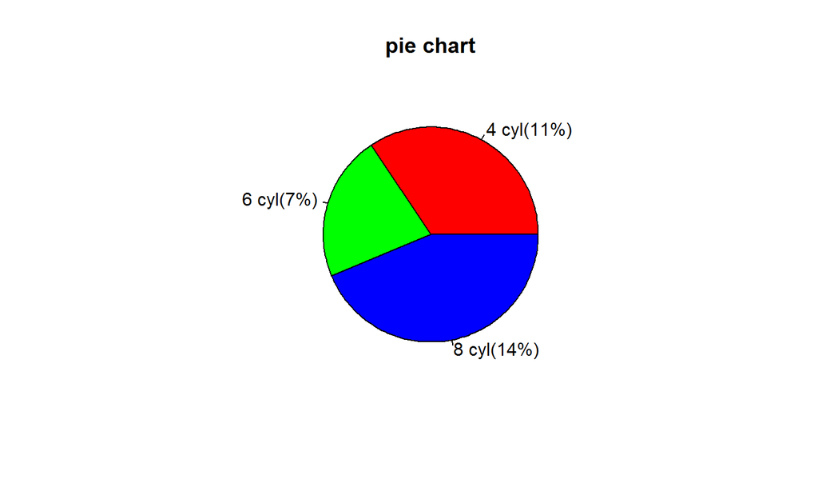

## 3d-pie chart

- plotrix(): 3차원 형태의 pie-chart 작성

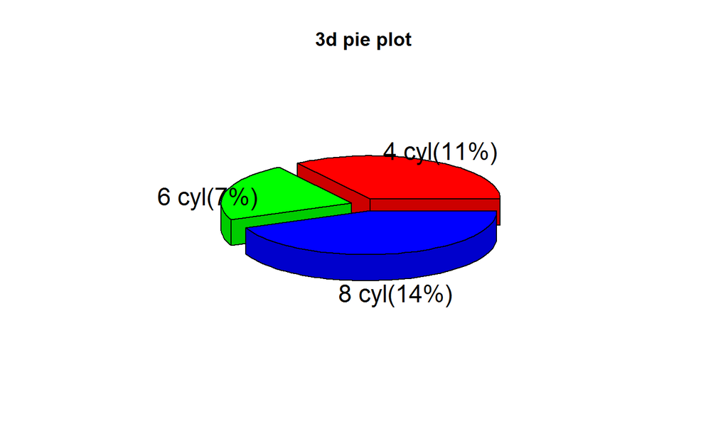

```r
if(!require(plotrix)){install.packages("plotrix"); library(plotrix)}
pie3D(freq.cyl, labels = cyl.name2, explode = 0.1, main = "3d pie plot")
```

## fan plot

- fan.plot(): 범주의 레벨 간 비교가 용이함

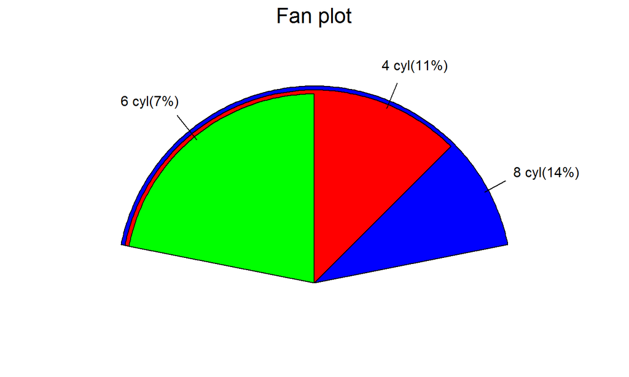

```r
fan.plot(freq.cyl, labels = cyl.name2, main = "Fan plot")
```

## Frequency of mutivariate variables

## introduction

- 두개 이상의 범주를 가진 데이터에서 빈도를 분석하고자 함
  - 예: (혈액형, 성별), (투약여부, 병증의 개선 정도)
- 빈도 데이블의 작성 및 시각화
  - 빈도테이블의 작성: `xtabs` 함수 이용
  - 시각화: `barplot()`, `spine()` 함수의 이용

## Frequency table

```r
if(!require(vcd)){install.packages("vcd"); library(vcd)}

head(Arthritis, n = 3)
```

```
##   ID Treatment  Sex Age Improved
## 1 57   Treated Male  27     Some
## 2 46   Treated Male  29     None
## 3 77   Treated Male  30     None
```

- 데이터: 류마티스 관절염에 대한 의학 실험데이터
  - ID , 처치(Treatment), 성별(Sex), 나이(Age), 개선정도(Improved)

## Frequency table

```r
my.table <- xtabs( ~ Treatment + Improved, data = Arthritis)
my.table
```

```
##          Improved
## Treatment None Some Marked
##   Placebo   29    7      7
##   Treated   13    7     21
```

- 빈도분석: 처치여부와 개선정도의 빈도 분석
  - `~ Treatment + Improved`
- `xtab()` 함수는 table 변수보다 직관적으로 빈도분석 툴을 제공

## barplot

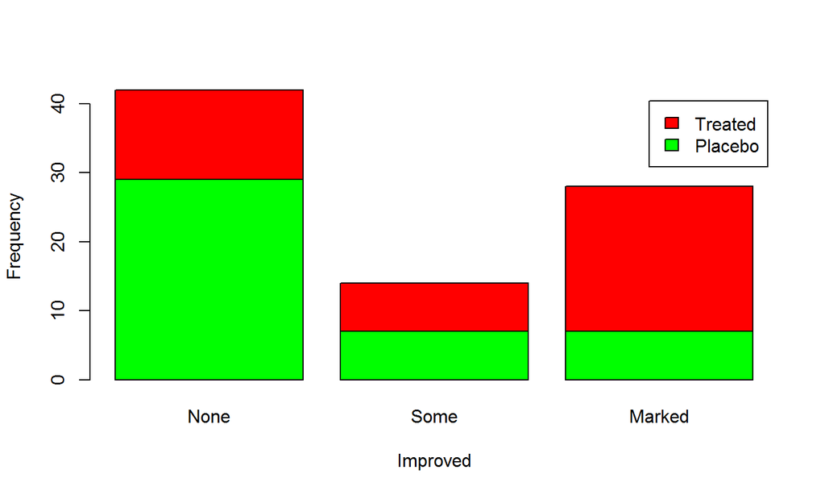

```r
barplot( my.table,
         xlab = "Improved", ylab = "Frequency", legend.text = TRUE,
         col = c("green", "red"))
```

## barplot

```r
barplot( t(my.table),
         xlab = "Improved", ylab = "Frequency", legend.text = TRUE,
         col = c("green", "red", "orange"))
```

- 처치 여부에 따른 개선정도의 차이를 확인하기 위해 데이터의 행과 열을 바꾼다.
  - `t(mytable)`
  - 색깔이 세가지가 필요하므로 `col`에 orange 색 추가

```r
t(my.table)
```

```
##         Treatment
## Improved Placebo Treated
##   None        29      13
##   Some         7       7
##   Marked       7      21
```

## barplot

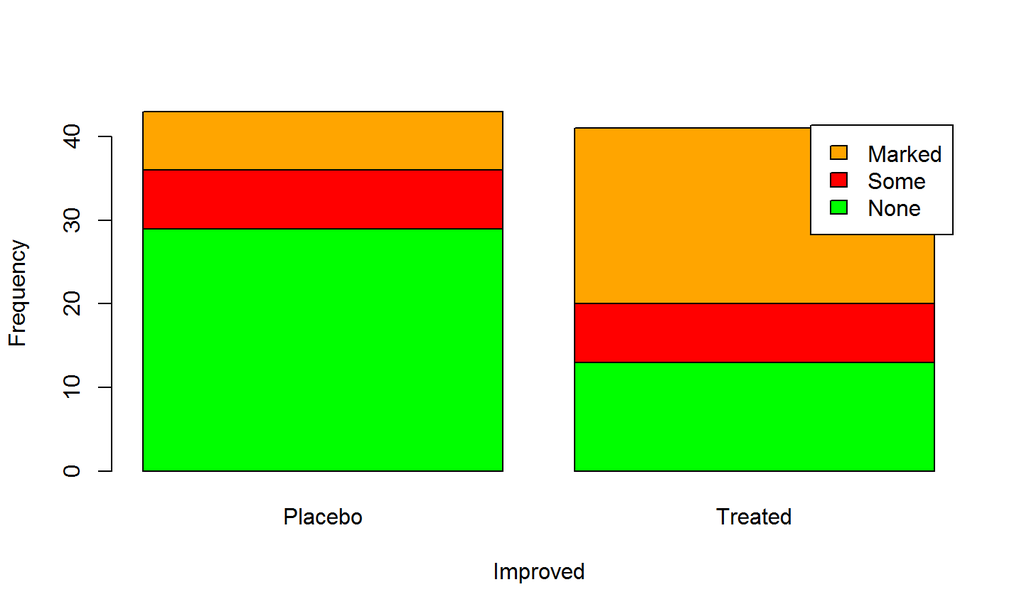

## barplot

- 부모님의 안전벨트 착용 유무와 자녀의 안전벨트 착용 유무의 비교

```r
tmp = c("buckled", "unbuckled")
belt <- matrix( c(58, 2, 8, 16), ncol = 2,
                dimnames = list(parent = tmp, child = tmp))
belt
```

```
##            child
## parent      buckled unbuckled
##   buckled        58         8
##   unbuckled       2        16
```

## barplot

- `spine()` 함수는 두 막대의 크기를 같게 만들어 비율의 차이를 비교하기 쉽게 할 수 있다.
- 막대의 밑변길이를 조정하여 면적이 전체에서 차지하는 비율로 표시할 수 있게 한다.

## barplot

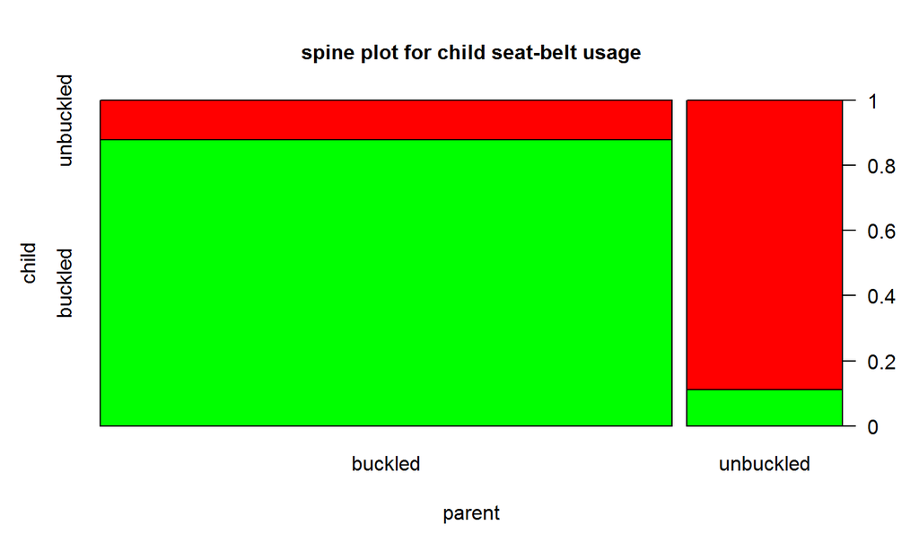

```r
spine(belt, main="spine plot for child seat-belt usage",
      gp = gpar(fill = c("green", "red")))
```

## continuous variables and visualization

## introduction

- 연속형 자료를 요약하고 시각화 한다.
  - 연속형 자료의 예: 키, 몸무게, 주가…
  - 연속형 자료의 요약치: 평균, 중앙값, 분위수…
  - 연속형 자료으 시각화 도구: boxplot, 히스토그램, 바이올린 플롯

## boxplot

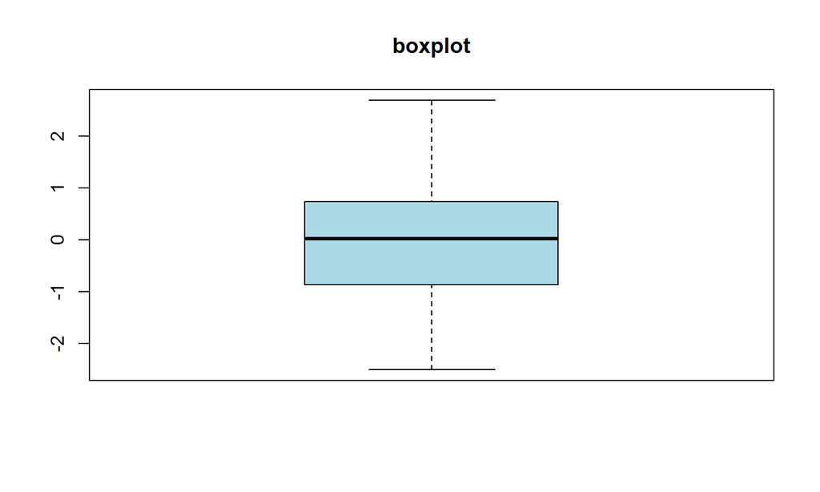

```r
x = rnorm(100)
boxplot(x, main = "boxplot", col ='lightblue')
```

## boxplot

- 진한 검은색 선: 중앙값
  - 데이터의 중심측도
- 상자: 상위 25%, 하위 25%
  - 상자의 크기는 데이터의 산포측도 (IQR: inter-quantile-range)
- 날개: 위쪽 날개는 상위 25% 값보다 1.5배 안쪽에 있는 값 중 최대, 아랫쪽 날개는 하위 25%보다 1.5배 안쪽에 있는 값 중 최소.
  - 극단값의 식별

## histogram

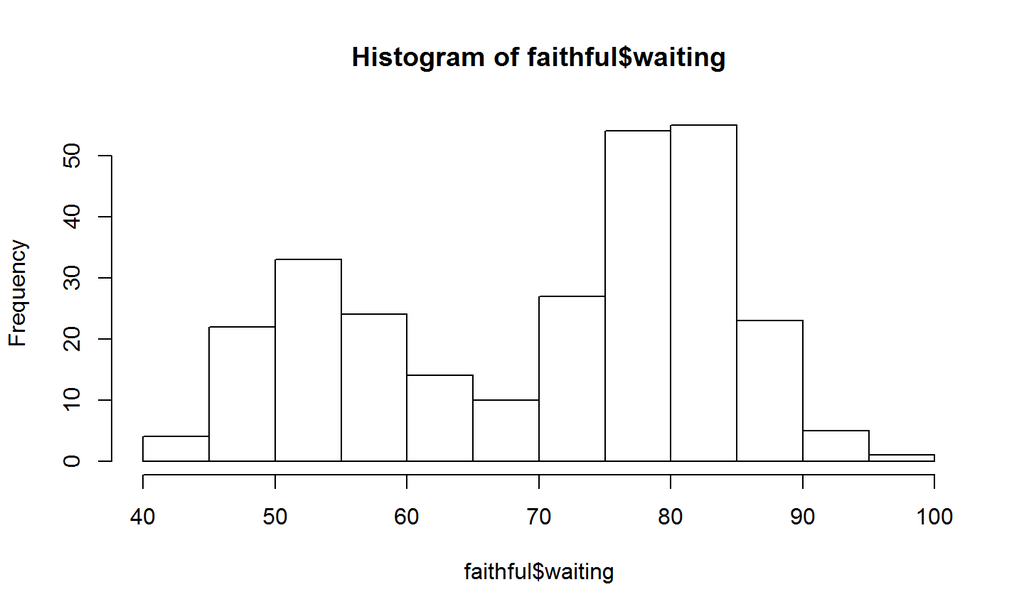

```r
x = faithful$waiting
hist(faithful$waiting, nclass = 8)
```

## histogram

- `hist()` 함수는 히스토그램을 생성한다.
  - 히스토그램의 형태는 계급구간을 어떻게 설정하는가에 따라 달라진다.
  - 주로 `nclass` 에 개수를 입력하여 계급구간의 설정한다.
  - 정확한 계급구간은 `break` 옵션을 통해 정의할 수 있다.
  - 히스토그램의 높이를 확률로 표시하기 위해서 `probability=T`를 사용한다.
- 히스토그램은 연속형 자료의 분포를 보여주는 시각도구

## histogram

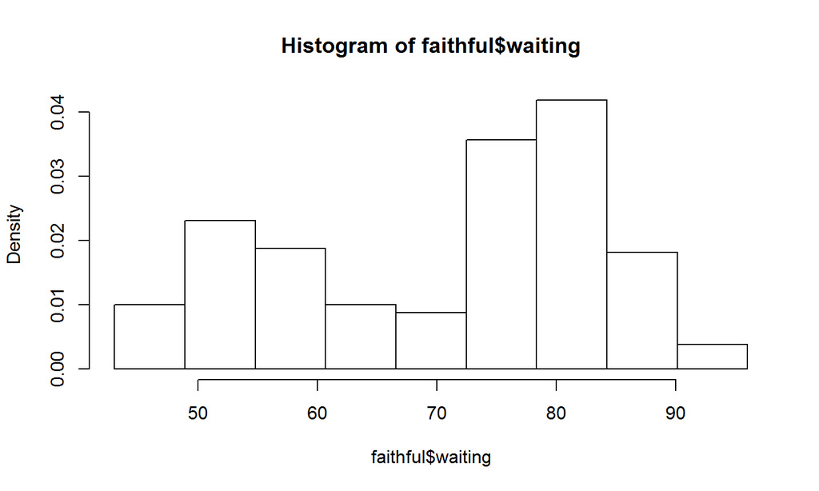

```r
x = faithful$waiting
hist(faithful$waiting, breaks = seq(min(x), max(x), length = 10),
     probability = T)
```

## histogram

- `density()` 함수를 이용해서 확률밀도함수의 추가할 수 있다.

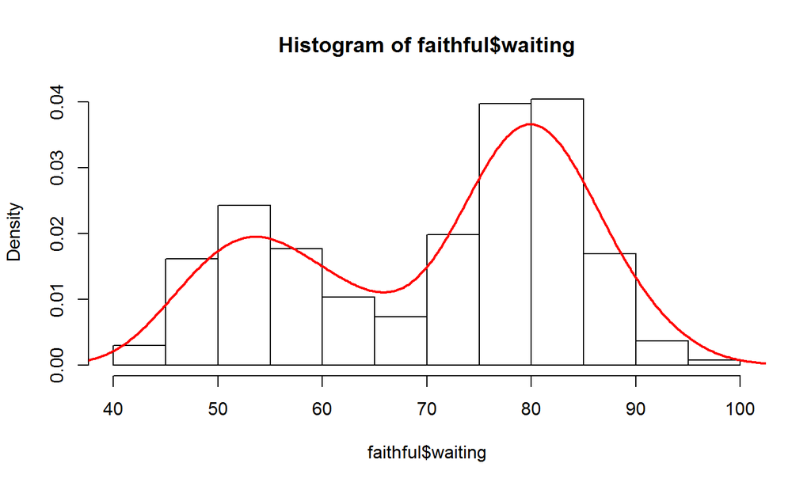

```r
x = faithful$waiting
hist(faithful$waiting, nclass = 10, probability = T)
lines(density(x), col = "red", lwd = 2)
```

## violin plot

- violin plot은 boxplot의 장점과 histogram의 장점을 결합한 시각화 도구다.

```r
if(!require(vioplot)){install.packages("vioplot"); library(vioplot)}

x = rpois(1000, lambda = 3)
vioplot(x, col = "lightblue")
```

## violin plot

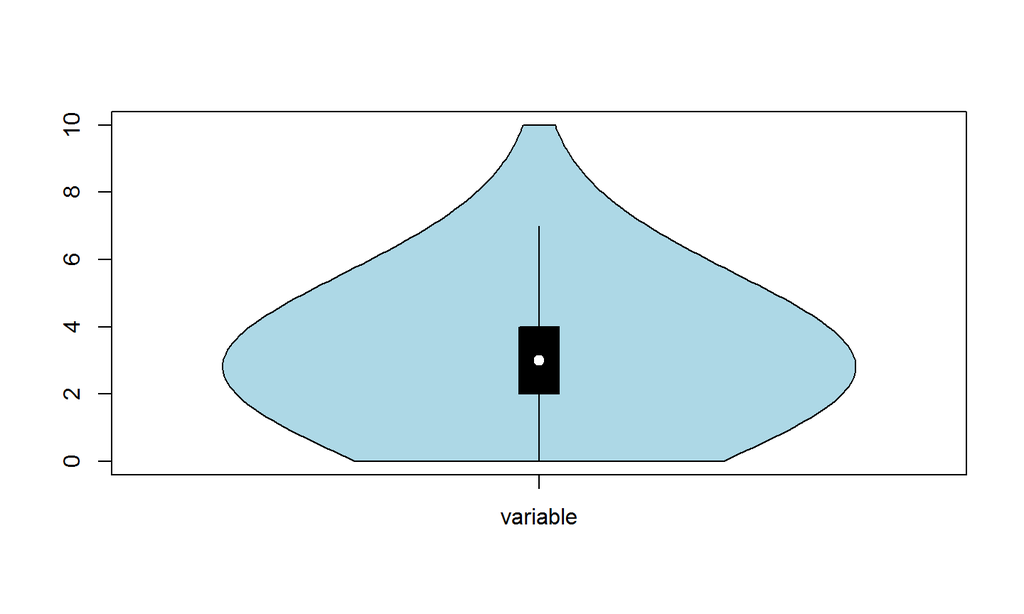

## visualization for mutivariate variables

## multiple boxplot

- `boxplot()`을 이용해서 연속형 분포의 요약 통계량을 동시에 비교할 수 있음
- `mpg~cyl`은 y축을 `mpg`변수 x축을 `cyl`변수로 하겠다는 의미임.

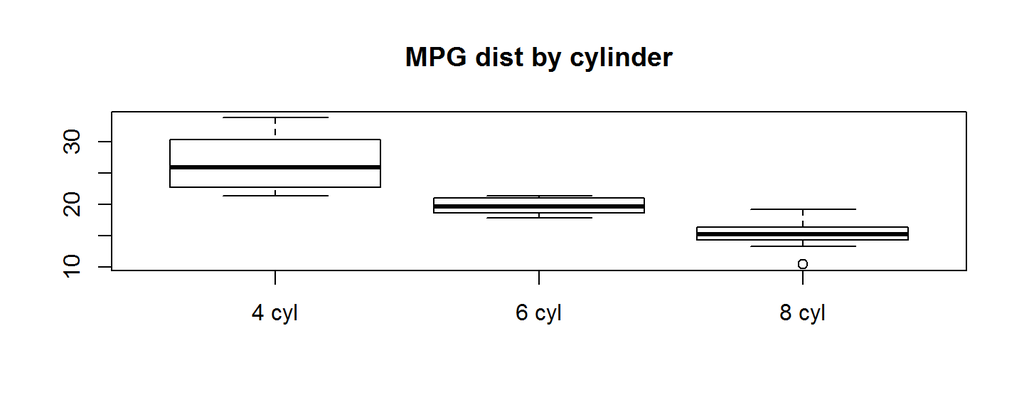

```r
attach(mtcars)
boxplot(mpg~cyl, data = mtcars, names = c('4 cyl','6 cyl', '8 cyl'),
        main = "MPG dist by cylinder")
```

## multiple histogram

- 히스토그램을 겹쳐 그리기: (좋지 않은 방법)

```r
hist(mpg[cyl==4], xlab="MPG", main = "MPG dist by cylinder",
     xlim = c(5, 40),  ylim = c(0,10), col = 'lightblue',
     nclass = trunc(sqrt(length(mpg[cyl==4]))))
hist(mpg[cyl==6], xlab="MPG", main = "MPG dist by cylinder",
     xlim = c(5, 40),  ylim = c(0,10), col = 'orange',
     nclass = trunc(sqrt(length(mpg[cyl==6]))), add= TRUE)
hist(mpg[cyl==8], xlab="MPG", main = "MPG dist by cylinder",
     xlim = c(5, 40),  ylim = c(0,10), col = 'red',
     nclass = trunc(sqrt(length(mpg[cyl==8]))), add= TRUE)
```

## multiple histogram

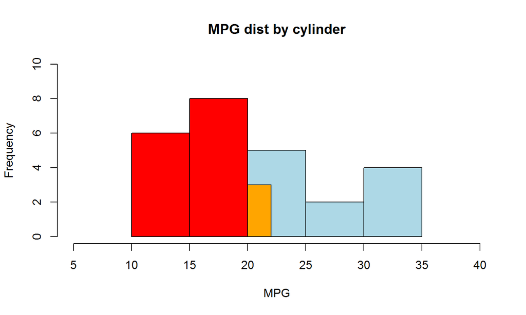

## multiple histogram

[figure not shown]

```
Visualization  의 나쁜 예
```

## multiple histogram

```
* par의 mfrow 옵셥을 이용하여 3개의 히스토그램을 수직으로 배열
* xlim 을 맞추어야 데이터의 중심비교가 용이함
```

```r
par(mfrow = c(3,1))
hist(mpg[cyl==4], xlab="MPG", main = "MPG dist by cylinder",
     xlim = c(5, 40),  ylim = c(0,10), col = 'lightblue',
     nclass = trunc(sqrt(length(mpg[cyl==4]))))
hist(mpg[cyl==6], xlab="MPG", main = "MPG dist by cylinder",
     xlim = c(5, 40),  ylim = c(0,10), col = 'orange',
     nclass = trunc(sqrt(length(mpg[cyl==6]))))
hist(mpg[cyl==8], xlab="MPG", main = "MPG dist by cylinder",
     xlim = c(5, 40),  ylim = c(0,10), col = 'red',
     nclass = trunc(sqrt(length(mpg[cyl==8]))))
```

## multiple histogram

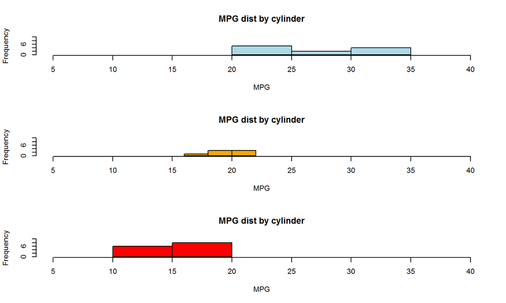

## multiple densities

```
* 확률밀도함수를 한번에 표현할 수 있음
```

```r
plot(density(mpg[cyl==4]), xlab="MPG", main = "MPG dist by cylinder",
     xlim = c(5, 40), ylim = c(0.,0.26))
lines(density(mpg[cyl==6]), col = "red", lty = 2)
lines(density(mpg[cyl==8]), col = "blue", lty = 3)
legend("topright", paste(c(4,6,8), "Cylinder"),
       col = c("black","red", "blue"),
       lty = c(1,2,3), lwd = 3, bty ="n")
```

## multiple densities

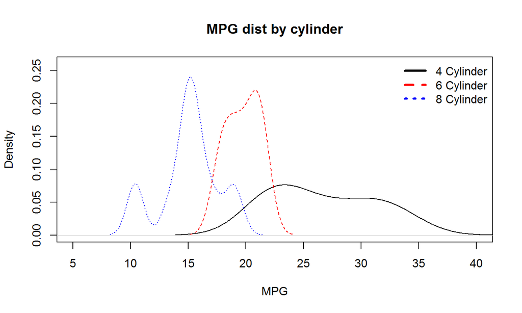

## 실습

- 부모님의 안전벨트 착용 유무와 자녀의 안전벨트 착용 유무의 비교예제

```r
tmp = c("buckled", "unbuckled")
belt <- matrix( c(58, 2, 8, 16), ncol = 2,
                dimnames = list(parent = tmp, child = tmp))
belt
```

```
##            child
## parent      buckled unbuckled
##   buckled        58         8
##   unbuckled       2        16
```

## 실습

- 부모의 안전벨트 착용이 자식간의 안전벨트 착용에 영향을 준다는 것을 시각화하여 보여라.

## 실습

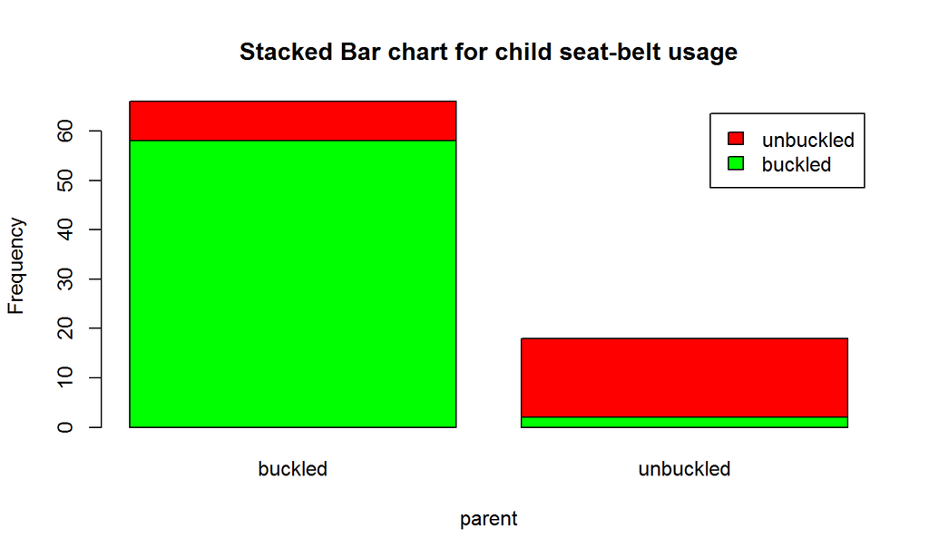

```r
barplot( t(belt), main = "Stacked Bar chart for child seat-belt usage",
         xlab = "parent", ylab = "Frequency", legend.text = TRUE,
         col = c("green", "red"))
```